# parks

## Public parks in San Francisco

This notebook attempts to locate all the public parks in San Francisco. One of my goals in 2025 is to visit every park in the city.

I figure it'd be too difficult to rigorously do this from google maps on my phone, so I reached for openstreetmaps and the associated ecosystem. It did not disappoint!

This notebook was used to gather the data for https://parks.dxuuu.xyz/.

```python
import osmnx
import folium

tags = {
    'leisure': 'park',
    # Could also include: 'garden', 'nature_reserve' depending on your needs
}

sf_boundary = osmnx.geocode_to_gdf("San Francisco, California")

parks = osmnx.features_from_polygon(
    sf_boundary.geometry.iloc[0],
    tags=tags
)
parks
```

| element | id | geometry | ele | gnis:feature_id | leisure | name | wikidata | wikipedia | historic | opening_hours | smoking | ... | leaf_type | acres | communication:amateur_radio:pota | name:pt | tourism | fee | location | type | disused:landuse | source:operator |
| --- | --- | --- | --- | --- | --- | --- | --- | --- | --- | --- | --- | --- | --- | --- | --- | --- | --- | --- | --- | --- | --- | --- |
| node | 358767175 | POINT (-122.49088 37.72237) | 16 | 224922 | park | Harding Park | Q49497924 | NaN | NaN | NaN | NaN | ... | NaN | NaN | NaN | NaN | NaN | NaN | NaN | NaN | NaN | NaN |
|  | 358803650 | POINT (-122.40303 37.79687) | 7 | 1655668 | park | Jackson Square Historic District | Q49506269 | NaN | district | NaN | NaN | ... | NaN | NaN | NaN | NaN | NaN | NaN | NaN | NaN | NaN | NaN |
|  | 358803668 | POINT (-122.49942 37.72549) | 8 | 1655678 | park | Lake Merced Sports Center | NaN | NaN | NaN | NaN | NaN | ... | NaN | NaN | NaN | NaN | NaN | NaN | NaN | NaN | NaN | NaN |
|  | 358803681 | POINT (-122.41367 37.72248) | 55 | 1655685 | park | Louis Sutter Playground | Q49519583 | NaN | NaN | NaN | NaN | ... | NaN | NaN | NaN | NaN | NaN | NaN | NaN | NaN | NaN | NaN |
|  | 358803706 | POINT (-122.37692 37.72965) | 56 | 1655701 | park | Milton Myer Recreation Center | Q49526782 | NaN | NaN | NaN | NaN | ... | NaN | NaN | NaN | NaN | NaN | NaN | NaN | NaN | NaN | NaN |
| ... | ... | ... | ... | ... | ... | ... | ... | ... | ... | ... | ... | ... | ... | ... | ... | ... | ... | ... | ... | ... | ... | ... |
| way | 1286999777 | POLYGON ((-122.39559 37.79113, -122.3952 37.79... | NaN | NaN | park | Urban Park | NaN | NaN | NaN | Mo-Fr 08:00-20:00 | NaN | ... | NaN | NaN | NaN | NaN | NaN | NaN | NaN | NaN | NaN | NaN |
|  | 1293746220 | POLYGON ((-122.47178 37.75073, -122.47106 37.7... | NaN | NaN | park | Mandalay Lane Park | NaN | NaN | NaN | NaN | NaN | ... | NaN | NaN | NaN | NaN | NaN | NaN | NaN | NaN | NaN | NaN |
|  | 1293746848 | POLYGON ((-122.48591 37.75188, -122.4818 37.75... | NaN | NaN | park | Sunset Reservoir Park | NaN | NaN | NaN | 24/7 | NaN | ... | NaN | NaN | NaN | NaN | NaN | NaN | NaN | NaN | NaN | NaN |
|  | 1300623937 | POLYGON ((-122.44574 37.75953, -122.44508 37.7... | NaN | NaN | park | Al's Park | NaN | NaN | NaN | NaN | NaN | ... | NaN | NaN | NaN | NaN | NaN | NaN | NaN | NaN | NaN | NaN |
|  | 1329130170 | POLYGON ((-122.38623 37.7696, -122.38616 37.76... | NaN | NaN | park | Bayfront Park | NaN | NaN | NaN | sunrise-sunset | NaN | ... | NaN | NaN | NaN | NaN | NaN | NaN | NaN | NaN | NaN | NaN |

340 rows × 98 columns

```python
park_names = parks['name'].tolist()
park_names
```

```
['Harding Park',
 'Jackson Square Historic District',
 'Lake Merced Sports Center',
 'Louis Sutter Playground',
 'Milton Myer Recreation Center',
 'Rolph-Nicol Playground',
 'Farallon Islands State Game Refuge',
 'Bush Street-Cottage Row Historic District',
 'Russian Hill-Vallejo Street Crest Historic District',
 'Ulrich Field',
 'Benedetti Diamond',
 'Fairy Circle',
 'Secret Garden',
 'Annie St Plaza',
 'Maritime Plaza',
 'Lands End',
 'China Beach',
 "Saint Mary's Park",
 'Presidio of San Francisco',
 'Lincoln Park',
 'Salesforce Park',
 'Brotherhood-Head Mini Park',
 'Sue Bierman Park',
 'Mount Davidson Park',
 'Buena Vista Park',
 'McCoppin Square',
 'Panhandle',
 'Alta Plaza Park',
 'Lafayette Park',
 'Bernal Heights Park',
 'Holly Park',
 'Marina Green',
 'Washington Square Park',
 'South Beach Park',
 'Jackson Park',
 'Mission Dolores Park',
 'Rolph Playground',
 'Precita Park',
 'Sydney G. Walton Square',
 'South Park',
```

[output cut: 285 more lines]

```
 'Pier 29 Public Shore',
 'The Commons',
 nan,
 'moscone dog play area',
 'Buckeye Grove',
 'Panorama Park',
 'Clipper Cove Beach',
 'Rincon Place',
 'Ecker Square',
 'Urban Alchemy Oasis',
 'Urban Park',
 'Mandalay Lane Park',
 'Sunset Reservoir Park',
 "Al's Park",
 'Bayfront Park']
```

## Define thumbnail helper

This helper generates a park map thumbnail given a row in parks dataset.

```python
def generate_park_map(row, zoom=15):
    # Map to longitude and latitude
    longitude = row.geometry.centroid.x
    latitude = row.geometry.centroid.y

    # Create figure with an appropriate aspect ratio
    m = folium.Map(
        location=[latitude, longitude],
        zoom_start=zoom,
        tiles='OpenStreetMap',
    )

    folium.Marker(
        [latitude, longitude],
        popup=folium.Popup(row['name'], max_width=300, auto_open=True)
    ).add_to(m)

    return m
```

```python
generate_park_map(parks.iloc[0])
```

Make this Notebook Trusted to load map: File -> Trust Notebook

[interactive chart not shown]

## Investigate NaN name parks

Now that we know the data is reasonable, let's look at anomalies. There's a few parks with NaN for name, so let's see if they're valid parks.

```python
no_name_parks = parks.query('name.isna()')
no_name_parks
```

| element | id | geometry | ele | gnis:feature_id | leisure | name | wikidata | wikipedia | historic | opening_hours | smoking | ... | leaf_type | acres | communication:amateur_radio:pota | name:pt | tourism | fee | location | type | disused:landuse | source:operator |
| --- | --- | --- | --- | --- | --- | --- | --- | --- | --- | --- | --- | --- | --- | --- | --- | --- | --- | --- | --- | --- | --- | --- |
| way | 30029902 | POLYGON ((-122.41934 37.80672, -122.41897 37.8... | NaN | NaN | park | NaN | NaN | NaN | NaN | NaN | NaN | ... | NaN | NaN | NaN | NaN | NaN | NaN | NaN | NaN | NaN | NaN |
|  | 32862942 | POLYGON ((-122.39404 37.79096, -122.394 37.790... | NaN | NaN | park | NaN | NaN | NaN | NaN | Mo-Fr 08:00-20:00 | NaN | ... | NaN | NaN | NaN | NaN | NaN | NaN | NaN | NaN | NaN | NaN |
|  | 33883156 | POLYGON ((-122.41934 37.79765, -122.41932 37.7... | NaN | NaN | park | NaN | NaN | NaN | NaN | 05:00-24:00 | no | ... | NaN | NaN | NaN | NaN | NaN | NaN | NaN | NaN | NaN | NaN |
|  | 41373180 | POLYGON ((-122.46506 37.73889, -122.46472 37.7... | NaN | NaN | park | NaN | NaN | NaN | NaN | NaN | NaN | ... | NaN | NaN | NaN | NaN | NaN | NaN | NaN | NaN | NaN | NaN |
|  | 48537425 | POLYGON ((-122.47418 37.72429, -122.47418 37.7... | NaN | NaN | park | NaN | NaN | NaN | NaN | NaN | NaN | ... | NaN | NaN | NaN | NaN | NaN | NaN | NaN | NaN | NaN | NaN |
|  | 69422745 | POLYGON ((-122.44674 37.80187, -122.44723 37.8... | NaN | NaN | park | NaN | NaN | NaN | NaN | NaN | NaN | ... | NaN | NaN | NaN | NaN | NaN | NaN | NaN | NaN | NaN | NaN |
|  | 84812337 | POLYGON ((-122.38706 37.77128, -122.3867 37.77... | NaN | NaN | park | NaN | NaN | NaN | NaN | NaN | NaN | ... | NaN | NaN | NaN | NaN | NaN | NaN | NaN | NaN | NaN | NaN |
|  | 85891398 | POLYGON ((-122.43321 37.74195, -122.43334 37.7... | NaN | NaN | park | NaN | NaN | NaN | NaN | NaN | NaN | ... | NaN | NaN | NaN | NaN | NaN | NaN | NaN | NaN | NaN | NaN |
|  | 85930055 | POLYGON ((-122.46371 37.75846, -122.46318 37.7... | NaN | NaN | park | NaN | NaN | NaN | NaN | NaN | NaN | ... | NaN | NaN | NaN | NaN | NaN | NaN | NaN | NaN | NaN | NaN |
|  | 91913157 | POLYGON ((-122.40898 37.80847, -122.40896 37.8... | NaN | NaN | park | NaN | NaN | NaN | NaN | NaN | NaN | ... | NaN | NaN | NaN | NaN | NaN | NaN | NaN | NaN | NaN | NaN |
|  | 157018893 | POLYGON ((-122.44365 37.7608, -122.44354 37.76... | NaN | NaN | park | NaN | NaN | NaN | NaN | NaN | NaN | ... | NaN | NaN | NaN | NaN | NaN | NaN | NaN | NaN | NaN | NaN |
|  | 161843752 | POLYGON ((-122.4358 37.8066, -122.43559 37.806... | NaN | NaN | park | NaN | NaN | NaN | NaN | NaN | NaN | ... | NaN | NaN | NaN | NaN | NaN | NaN | NaN | NaN | NaN | NaN |
|  | 219036273 | POLYGON ((-122.44008 37.76212, -122.44007 37.7... | NaN | NaN | park | NaN | NaN | NaN | NaN | NaN | NaN | ... | NaN | NaN | NaN | NaN | NaN | NaN | NaN | NaN | NaN | NaN |
|  | 382113061 | POLYGON ((-122.44536 37.76337, -122.4454 37.76... | NaN | NaN | park | NaN | NaN | NaN | NaN | NaN | NaN | ... | NaN | NaN | NaN | NaN | NaN | NaN | NaN | NaN | NaN | NaN |
|  | 399402796 | POLYGON ((-122.47126 37.77316, -122.47141 37.7... | NaN | NaN | park | NaN | NaN | NaN | NaN | NaN | NaN | ... | NaN | NaN | NaN | NaN | NaN | NaN | NaN | NaN | NaN | NaN |
|  | 401354282 | POLYGON ((-122.47284 37.78631, -122.47314 37.7... | NaN | NaN | park | NaN | NaN | NaN | NaN | NaN | NaN | ... | NaN | NaN | NaN | NaN | NaN | NaN | NaN | NaN | NaN | NaN |
|  | 404847042 | POLYGON ((-122.49831 37.7315, -122.49831 37.73... | NaN | NaN | park | NaN | NaN | NaN | NaN | NaN | NaN | ... | NaN | NaN | NaN | NaN | NaN | NaN | NaN | NaN | NaN | NaN |
|  | 407324072 | POLYGON ((-122.41913 37.77138, -122.41912 37.7... | NaN | NaN | park | NaN | NaN | NaN | NaN | NaN | NaN | ... | NaN | NaN | NaN | NaN | NaN | NaN | NaN | NaN | NaN | NaN |
|  | 414135696 | POLYGON ((-122.49368 37.73306, -122.49356 37.7... | NaN | NaN | park | NaN | NaN | NaN | NaN | NaN | NaN | ... | NaN | NaN | NaN | NaN | NaN | NaN | NaN | NaN | NaN | NaN |
|  | 414135697 | POLYGON ((-122.49437 37.73479, -122.49433 37.7... | NaN | NaN | park | NaN | NaN | NaN | NaN | NaN | NaN | ... | NaN | NaN | NaN | NaN | NaN | NaN | NaN | NaN | NaN | NaN |
|  | 414135698 | POLYGON ((-122.49321 37.73205, -122.49356 37.7... | NaN | NaN | park | NaN | NaN | NaN | NaN | NaN | NaN | ... | NaN | NaN | NaN | NaN | NaN | NaN | NaN | NaN | NaN | NaN |
|  | 414135699 | POLYGON ((-122.49398 37.73304, -122.49396 37.7... | NaN | NaN | park | NaN | NaN | NaN | NaN | NaN | NaN | ... | NaN | NaN | NaN | NaN | NaN | NaN | NaN | NaN | NaN | NaN |
|  | 414135700 | POLYGON ((-122.49348 37.73413, -122.49352 37.7... | NaN | NaN | park | NaN | NaN | NaN | NaN | NaN | NaN | ... | NaN | NaN | NaN | NaN | NaN | NaN | NaN | NaN | NaN | NaN |
|  | 414135702 | POLYGON ((-122.4934 37.72975, -122.49337 37.72... | NaN | NaN | park | NaN | NaN | NaN | NaN | NaN | NaN | ... | NaN | NaN | NaN | NaN | NaN | NaN | NaN | NaN | NaN | NaN |
|  | 414135703 | POLYGON ((-122.49428 37.732, -122.49423 37.731... | NaN | NaN | park | NaN | NaN | NaN | NaN | NaN | NaN | ... | NaN | NaN | NaN | NaN | NaN | NaN | NaN | NaN | NaN | NaN |
|  | 414135705 | POLYGON ((-122.49393 37.74235, -122.49549 37.7... | NaN | NaN | park | NaN | NaN | NaN | NaN | NaN | NaN | ... | NaN | NaN | NaN | NaN | NaN | NaN | NaN | NaN | NaN | NaN |
|  | 414135706 | POLYGON ((-122.49425 37.74037, -122.49413 37.7... | NaN | NaN | park | NaN | NaN | NaN | NaN | NaN | NaN | ... | NaN | NaN | NaN | NaN | NaN | NaN | NaN | NaN | NaN | NaN |
|  | 414135707 | POLYGON ((-122.49453 37.74213, -122.49499 37.7... | NaN | NaN | park | NaN | NaN | NaN | NaN | NaN | NaN | ... | NaN | NaN | NaN | NaN | NaN | NaN | NaN | NaN | NaN | NaN |
|  | 414135708 | POLYGON ((-122.49427 37.73181, -122.49416 37.7... | NaN | NaN | park | NaN | NaN | NaN | NaN | NaN | NaN | ... | NaN | NaN | NaN | NaN | NaN | NaN | NaN | NaN | NaN | NaN |
|  | 414135709 | POLYGON ((-122.49389 37.73511, -122.49399 37.7... | NaN | NaN | park | NaN | NaN | NaN | NaN | NaN | NaN | ... | NaN | NaN | NaN | NaN | NaN | NaN | NaN | NaN | NaN | NaN |
|  | 414135710 | POLYGON ((-122.49441 37.74036, -122.49428 37.7... | NaN | NaN | park | NaN | NaN | NaN | NaN | NaN | NaN | ... | NaN | NaN | NaN | NaN | NaN | NaN | NaN | NaN | NaN | NaN |
|  | 458217887 | POLYGON ((-122.42382 37.77434, -122.42374 37.7... | NaN | NaN | park | NaN | NaN | NaN | NaN | NaN | NaN | ... | NaN | NaN | NaN | NaN | NaN | NaN | NaN | NaN | NaN | NaN |
|  | 488800989 | POLYGON ((-122.41066 37.72666, -122.41039 37.7... | NaN | NaN | park | NaN | NaN | NaN | NaN | NaN | NaN | ... | NaN | NaN | NaN | NaN | NaN | NaN | NaN | NaN | NaN | NaN |
|  | 545347966 | POLYGON ((-122.4327 37.78347, -122.43263 37.78... | NaN | NaN | park | NaN | NaN | NaN | NaN | NaN | NaN | ... | NaN | NaN | NaN | NaN | NaN | NaN | NaN | NaN | NaN | NaN |
|  | 545436378 | POLYGON ((-122.42865 37.77927, -122.42866 37.7... | NaN | NaN | park | NaN | NaN | NaN | NaN | NaN | NaN | ... | NaN | NaN | NaN | NaN | NaN | NaN | NaN | NaN | NaN | NaN |
|  | 565996156 | POLYGON ((-122.36844 37.72777, -122.36833 37.7... | NaN | NaN | park | NaN | NaN | NaN | NaN | NaN | NaN | ... | NaN | NaN | NaN | NaN | NaN | NaN | NaN | NaN | NaN | NaN |
|  | 574610487 | POLYGON ((-122.40211 37.77003, -122.40201 37.7... | NaN | NaN | park | NaN | NaN | NaN | NaN | NaN | NaN | ... | NaN | NaN | NaN | NaN | NaN | NaN | NaN | NaN | NaN | NaN |
|  | 693102678 | POLYGON ((-122.47051 37.71211, -122.47089 37.7... | NaN | NaN | park | NaN | NaN | NaN | NaN | NaN | NaN | ... | NaN | NaN | NaN | NaN | NaN | NaN | NaN | NaN | NaN | NaN |
|  | 730336617 | POLYGON ((-122.40881 37.80823, -122.40883 37.8... | NaN | NaN | park | NaN | NaN | NaN | NaN | NaN | NaN | ... | NaN | NaN | NaN | NaN | NaN | NaN | NaN | NaN | NaN | NaN |
|  | 775796578 | POLYGON ((-122.37648 37.82303, -122.37602 37.8... | NaN | NaN | park | NaN | NaN | NaN | NaN | NaN | NaN | ... | NaN | NaN | NaN | NaN | NaN | NaN | NaN | NaN | NaN | NaN |
|  | 817076988 | POLYGON ((-122.38945 37.77214, -122.38945 37.7... | NaN | NaN | park | NaN | NaN | NaN | NaN | NaN | NaN | ... | NaN | NaN | NaN | NaN | NaN | NaN | NaN | NaN | NaN | NaN |
|  | 894478070 | POLYGON ((-122.44733 37.75461, -122.44821 37.7... | NaN | NaN | park | NaN | NaN | NaN | NaN | NaN | NaN | ... | NaN | NaN | NaN | NaN | NaN | NaN | NaN | NaN | NaN | NaN |
|  | 894478071 | POLYGON ((-122.44733 37.75461, -122.44741 37.7... | NaN | NaN | park | NaN | NaN | NaN | NaN | NaN | NaN | ... | NaN | NaN | NaN | NaN | NaN | NaN | NaN | NaN | NaN | NaN |
|  | 894529444 | POLYGON ((-122.38257 37.73112, -122.38243 37.7... | NaN | NaN | park | NaN | NaN | NaN | NaN | NaN | NaN | ... | NaN | NaN | NaN | NaN | NaN | NaN | NaN | NaN | NaN | NaN |
|  | 908050668 | POLYGON ((-122.43004 37.77972, -122.42996 37.7... | NaN | NaN | park | NaN | NaN | NaN | NaN | NaN | NaN | ... | NaN | NaN | NaN | NaN | NaN | NaN | NaN | NaN | NaN | NaN |
|  | 918133828 | POLYGON ((-122.39705 37.76157, -122.39694 37.7... | NaN | NaN | park | NaN | NaN | NaN | NaN | NaN | NaN | ... | NaN | NaN | NaN | NaN | NaN | NaN | NaN | NaN | NaN | NaN |
|  | 918165494 | POLYGON ((-122.3695 37.72682, -122.36947 37.72... | NaN | NaN | park | NaN | NaN | NaN | NaN | NaN | NaN | ... | NaN | NaN | NaN | NaN | NaN | NaN | NaN | NaN | NaN | NaN |
|  | 918165497 | POLYGON ((-122.37194 37.72697, -122.37189 37.7... | NaN | NaN | park | NaN | NaN | NaN | NaN | NaN | NaN | ... | NaN | NaN | NaN | NaN | NaN | NaN | NaN | NaN | NaN | NaN |
|  | 956484465 | POLYGON ((-122.37104 37.72715, -122.37093 37.7... | NaN | NaN | park | NaN | NaN | NaN | NaN | NaN | NaN | ... | NaN | NaN | NaN | NaN | NaN | NaN | NaN | NaN | NaN | NaN |
|  | 956484476 | POLYGON ((-122.37044 37.72678, -122.37029 37.7... | NaN | NaN | park | NaN | NaN | NaN | NaN | NaN | NaN | ... | NaN | NaN | NaN | NaN | NaN | NaN | NaN | NaN | NaN | NaN |
|  | 1047715315 | POLYGON ((-122.38854 37.77019, -122.38852 37.7... | NaN | NaN | park | NaN | NaN | NaN | NaN | NaN | NaN | ... | NaN | NaN | NaN | NaN | NaN | no | roof | NaN | NaN | NaN |
|  | 1047715319 | POLYGON ((-122.38838 37.7702, -122.38836 37.76... | NaN | NaN | park | NaN | NaN | NaN | NaN | NaN | NaN | ... | NaN | NaN | NaN | NaN | NaN | NaN | NaN | NaN | NaN | NaN |
|  | 1191526718 | POLYGON ((-122.38662 37.75431, -122.38662 37.7... | NaN | NaN | park | NaN | NaN | NaN | NaN | NaN | NaN | ... | NaN | NaN | NaN | NaN | NaN | NaN | NaN | NaN | NaN | NaN |
|  | 1195049111 | POLYGON ((-122.41337 37.73753, -122.41335 37.7... | NaN | NaN | park | NaN | NaN | NaN | NaN | NaN | NaN | ... | NaN | NaN | NaN | NaN | NaN | NaN | NaN | NaN | NaN | NaN |

54 rows × 98 columns

```python
generate_park_map(no_name_parks.iloc[1])
```

Make this Notebook Trusted to load map: File -> Trust Notebook

[interactive chart not shown]

## Disregard no-name parks and otherwise clean data

Looks like they are kinda valid parks. But small enough where they're unnamed. Let's just disregard them - they're probably not interesting to visit.

Also change `/` in park names to `-`. `/` Causes issues with filenames.

```python
named_parks = parks.query('not name.isna()')
named_parks = named_parks.copy()
named_parks['name'] = named_parks['name'].str.replace('/', '-')
named_parks
```

| element | id | geometry | ele | gnis:feature_id | leisure | name | wikidata | wikipedia | historic | opening_hours | smoking | ... | leaf_type | acres | communication:amateur_radio:pota | name:pt | tourism | fee | location | type | disused:landuse | source:operator |
| --- | --- | --- | --- | --- | --- | --- | --- | --- | --- | --- | --- | --- | --- | --- | --- | --- | --- | --- | --- | --- | --- | --- |
| node | 358767175 | POINT (-122.49088 37.72237) | 16 | 224922 | park | Harding Park | Q49497924 | NaN | NaN | NaN | NaN | ... | NaN | NaN | NaN | NaN | NaN | NaN | NaN | NaN | NaN | NaN |
|  | 358803650 | POINT (-122.40303 37.79687) | 7 | 1655668 | park | Jackson Square Historic District | Q49506269 | NaN | district | NaN | NaN | ... | NaN | NaN | NaN | NaN | NaN | NaN | NaN | NaN | NaN | NaN |
|  | 358803668 | POINT (-122.49942 37.72549) | 8 | 1655678 | park | Lake Merced Sports Center | NaN | NaN | NaN | NaN | NaN | ... | NaN | NaN | NaN | NaN | NaN | NaN | NaN | NaN | NaN | NaN |
|  | 358803681 | POINT (-122.41367 37.72248) | 55 | 1655685 | park | Louis Sutter Playground | Q49519583 | NaN | NaN | NaN | NaN | ... | NaN | NaN | NaN | NaN | NaN | NaN | NaN | NaN | NaN | NaN |
|  | 358803706 | POINT (-122.37692 37.72965) | 56 | 1655701 | park | Milton Myer Recreation Center | Q49526782 | NaN | NaN | NaN | NaN | ... | NaN | NaN | NaN | NaN | NaN | NaN | NaN | NaN | NaN | NaN |
| ... | ... | ... | ... | ... | ... | ... | ... | ... | ... | ... | ... | ... | ... | ... | ... | ... | ... | ... | ... | ... | ... | ... |
| way | 1286999777 | POLYGON ((-122.39559 37.79113, -122.3952 37.79... | NaN | NaN | park | Urban Park | NaN | NaN | NaN | Mo-Fr 08:00-20:00 | NaN | ... | NaN | NaN | NaN | NaN | NaN | NaN | NaN | NaN | NaN | NaN |
|  | 1293746220 | POLYGON ((-122.47178 37.75073, -122.47106 37.7... | NaN | NaN | park | Mandalay Lane Park | NaN | NaN | NaN | NaN | NaN | ... | NaN | NaN | NaN | NaN | NaN | NaN | NaN | NaN | NaN | NaN |
|  | 1293746848 | POLYGON ((-122.48591 37.75188, -122.4818 37.75... | NaN | NaN | park | Sunset Reservoir Park | NaN | NaN | NaN | 24/7 | NaN | ... | NaN | NaN | NaN | NaN | NaN | NaN | NaN | NaN | NaN | NaN |
|  | 1300623937 | POLYGON ((-122.44574 37.75953, -122.44508 37.7... | NaN | NaN | park | Al's Park | NaN | NaN | NaN | NaN | NaN | ... | NaN | NaN | NaN | NaN | NaN | NaN | NaN | NaN | NaN | NaN |
|  | 1329130170 | POLYGON ((-122.38623 37.7696, -122.38616 37.76... | NaN | NaN | park | Bayfront Park | NaN | NaN | NaN | sunrise-sunset | NaN | ... | NaN | NaN | NaN | NaN | NaN | NaN | NaN | NaN | NaN | NaN |

286 rows × 98 columns

## Sort by size

```python
# Project to web mercator
sized_parks = named_parks.copy().to_crs(3857)

# Calculate area in square meters
sized_parks['area'] = sized_parks.geometry.area

# Convert to acres
sized_parks['area_acres'] = (sized_parks.geometry.area / 4046.86).round(2)

# Maintain descending order
sized_parks.sort_values('area_acres', ascending=False, inplace=True)

sized_parks[['name', 'area_acres']]
```

| element | id | name | area_acres |
| --- | --- | --- | --- |
| relation | 8346137 | Presidio of San Francisco | 2411.04 |
| way | 158602261 | Golden Gate Park | 1611.13 |
|  | 404847043 | Lake Merced Park | 973.44 |
|  | 28716696 | John McLaren Park | 571.30 |
|  | 40060675 | Candlestick Point State Recreation Area | 250.48 |
| ... | ... | ... | ... |
| node | 12440345641 | Maritime Plaza | 0.00 |
|  | 358803668 | Lake Merced Sports Center | 0.00 |
|  | 358803681 | Louis Sutter Playground | 0.00 |
|  | 358803650 | Jackson Square Historic District | 0.00 |
|  | 358767175 | Harding Park | 0.00 |

286 rows × 2 columns

## Park size distribution

```
<module 'matplotlib.pyplot' from '/nix/store/1zyma6bfryj88cfdxs59phs5xzgmy5w9-python3-3.12.8-env/lib/python3.12/site-packages/matplotlib/pyplot.py'>
```

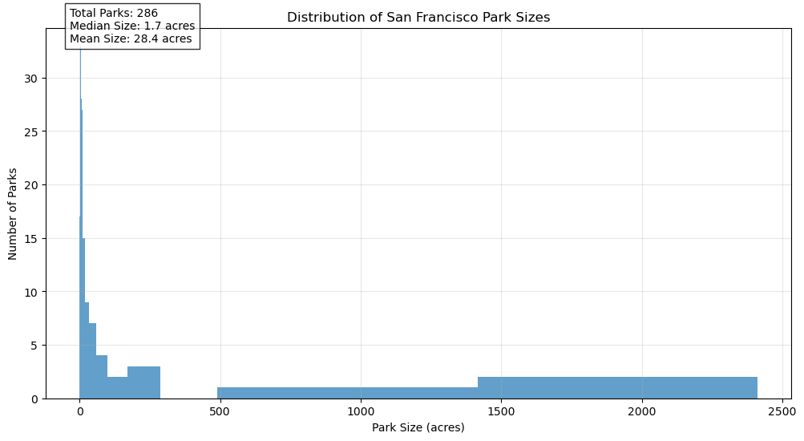

```python
import matplotlib.pyplot as plt
import numpy as np

def plot_park_size_distribution(sized_parks):
    """
    Create a histogram of park sizes with log scaling.
    Input: GeoDataFrame with 'area_acres' column
    """
    plt.figure(figsize=(12, 6))

    # Create histogram with log scale on x-axis due to likely long tail distribution
    plt.hist(sized_parks['area_acres'],
            bins=np.logspace(np.log10(0.1), np.log10(sized_parks['area_acres'].max()), 20),
            alpha=0.7)

    #plt.xscale('log')  # Log scale for x-axis since park sizes likely vary by orders of magnitude
    plt.xlabel('Park Size (acres)')
    plt.ylabel('Number of Parks')
    plt.title('Distribution of San Francisco Park Sizes')
    plt.grid(True, alpha=0.3)

    # Add some summary statistics
    plt.figtext(0.15, 0.85,
                f"Total Parks: {len(sized_parks)}\n"
                f"Median Size: {sized_parks['area_acres'].median():.1f} acres\n"
                f"Mean Size: {sized_parks['area_acres'].mean():.1f} acres",
                bbox=dict(facecolor='white', alpha=0.8))

    return plt

plot_park_size_distribution(sized_parks)
```

## Export data as HTML and JSON

We want to build a standalone webapp to track park visitation progress. So export this data into something a webapp can work with.

```python
import os
import json
from pathlib import Path

def generate_park_maps_and_data(sized_parks, named_parks):
    # Create maps directory if it doesn't exist
    Path("maps").mkdir(exist_ok=True)

    # Create dictionary for park sizes
    park_sizes = {}

    for idx, park in sized_parks.iterrows():
        name = str(park['name'])
        print(f"Generating map for: {name}")

        m = generate_park_map(named_parks[named_parks['name'] == name].iloc[0])
        m.save(f"maps/{name}.html")

        # Add to sizes dictionary
        park_sizes[name] = round(park.area_acres, 2)

    # Write JSON file
    with open('park_sizes.json', 'w') as f:
        json.dump(park_sizes, f, indent=2, sort_keys=True)

    print(f"\nGenerated {len(park_sizes)} maps")
    print("Park sizes saved to park_sizes.json")

generate_park_maps_and_data(sized_parks, named_parks)
```

```
Generating map for: Presidio of San Francisco
Generating map for: Golden Gate Park
Generating map for: Lake Merced Park
Generating map for: John McLaren Park
Generating map for: Candlestick Point State Recreation Area
Generating map for: Lands End
Generating map for: Lincoln Park
Generating map for: Glen Canyon Park
Generating map for: Fort Mason
Generating map for: Bayview Hill Park
Generating map for: Crocker Amazon Playground
Generating map for: Mount Davidson Park
Generating map for: Buena Vista Park
Generating map for: Sunset Reservoir Park
Generating map for: Sigmund Stern Recreation Grove
Generating map for: Bernal Heights Park
Generating map for: Pine Lake Park
Generating map for: Sutro Heights Park
Generating map for: Balboa Park
Generating map for: Panhandle
Generating map for: Heron's Head Park
Generating map for: Alcatraz Island
Generating map for: West Sunset Playground
Generating map for: Mission Dolores Park
Generating map for: Corona Heights Park
Generating map for: Presidio Tunnel Tops
Generating map for: Yosemite Slough
Generating map for: Mountain Lake Park
Generating map for: Alamo Square
Generating map for: Moscone Recreation Center
Generating map for: Alta Plaza Park
Generating map for: Lafayette Park
Generating map for: Ocean View Park
Generating map for: Potrero Hill Recreation Center
Generating map for: Pier 94 Wetlands
Generating map for: Saint Mary's Park
Generating map for: Mission Creek Park
Generating map for: Aquatic Park Historic District
Generating map for: Music Concourse
Generating map for: Parkside Square
```

[output cut: 234 more lines]

```
Generating map for: Bush Street-Cottage Row Historic District
Generating map for: Russian Hill-Vallejo Street Crest Historic District
Generating map for: Ulrich Field
Generating map for: Benedetti Diamond
Generating map for: Farallon Islands State Game Refuge
Generating map for: Rolph-Nicol Playground
Generating map for: Milton Myer Recreation Center
Generating map for: Maritime Plaza
Generating map for: Lake Merced Sports Center
Generating map for: Louis Sutter Playground
Generating map for: Jackson Square Historic District
Generating map for: Harding Park

Generated 281 maps
Park sizes saved to park_sizes.json
```

## Tarball the maps up for easier download

```python
import tarfile

def archive_maps_tar():
    with tarfile.open("maps.tar.gz", "w:gz") as tar:
        tar.add("maps")
    print("Created maps.tar.gz")

archive_maps_tar()
```

```
Created maps.tar.gz
```